# Lab #4 Team

Julia Lundstrum, Nikole Slinger, and Zack Larson

# Loading Data

```r
library(tidyverse)
```

```r
library(readxl)
defense <- read_excel('./cyclonesFootball2020.xlsx', sheet='Defensive')
offense <- read_excel('./cyclonesFootball2020.xlsx', sheet='Offensive')
biography <- read_excel('./cyclonesFootball2020.xlsx', sheet='Biography')
```

# Part One

Here we’ve successfully made the player and opponent name columns into factors. We then make all statistics numerical and separate columns as needed.

```r
# offense
offClean <- offense %>%
  mutate(across(c('Name','Opponent_Opponent'), as.factor)) %>%
  separate(`Passing_CMP-ATT`, c('Passing_CMP','Passing_ATT')) %>%
  mutate(across(c(3:13), as.numeric))
str(offense)
```

```
## tibble [156 × 12] (S3: tbl_df/tbl/data.frame)
##  $ Name             : chr [1:156] "Akers, Landen" "Akers, Landen" "Akers, Landen" "Akers, Landen" ...
##  $ Opponent_Opponent: chr [1:156] "Louisiana" "TCU" "Oklahoma" "Texas Tech" ...
##  $ Receiving_REC    : chr [1:156] "0" "2" "1" "4" ...
##  $ Receiving_YDS    : chr [1:156] "0" "60" "35" "34" ...
##  $ Receiving_TD     : chr [1:156] "0" "0" "0" "0" ...
##  $ Rushing_ATT      : chr [1:156] NA NA NA NA ...
##  $ Rushing_YDS      : chr [1:156] NA NA NA NA ...
##  $ Rushing_TD       : chr [1:156] NA NA NA NA ...
##  $ Passing_CMP-ATT  : chr [1:156] NA NA NA NA ...
##  $ Passing_YDS      : chr [1:156] NA NA NA NA ...
##  $ Passing_TD       : chr [1:156] NA NA NA NA ...
##  $ Passing_INT      : chr [1:156] NA NA NA NA ...
```

```r
# defense
defClean <- defense %>%
  mutate(across(c('Name','Opponent_Opponent'), as.factor)) %>%
  mutate(across(c(3:11), as.numeric))
str(defense)
```

```
## tibble [372 × 11] (S3: tbl_df/tbl/data.frame)
##  $ Name             : chr [1:372] "Rose, Mike" "Rose, Mike" "Rose, Mike" "Rose, Mike" ...
##  $ Opponent_Opponent: chr [1:372] "Louisiana" "TCU" "Oklahoma" "Texas Tech" ...
##  $ Tackles_Solo     : chr [1:372] "2" "6" "6" "3" ...
##  $ Tackles_ASST     : chr [1:372] "4" "4" "5" "0" ...
##  $ Tackles_TFL      : chr [1:372] "1.0" "0" "1.5" "1.0" ...
##  $ Tackles_Sack     : chr [1:372] "0" "0" "0.5" "0" ...
##  $ Turnover_FF      : chr [1:372] "0" "0" "0" "0" ...
##  $ Turnover_FR      : chr [1:372] "0" "0" "0" "0" ...
##  $ Turnover_INT     : chr [1:372] "0" "1" "0" "0" ...
##  $ Pass_QBH         : chr [1:372] "0" "0" "1" "0" ...
##  $ Pass_PB          : chr [1:372] "0" "0" "0" "0" ...
```

```r
# biography
bioClean <- biography %>%
  mutate(Name = as.factor(Name)) %>%
  separate(Height, c('Ft', 'In')) %>%
  mutate(across(c('Ft','In', 'Weight'), as.numeric), Height = 12 * Ft + In)
#Separated height and made new height column that is the total height in inches.
str(biography)
```

```
## tibble [116 × 7] (S3: tbl_df/tbl/data.frame)
##  $ Name      : chr [1:116] "Akers, Landen" "Allen, Chase" "Anderson, Ezeriah" "Antoine Jr. , Michal" ...
##  $ Position  : chr [1:116] "Wide Receiver" "Tight End" "Wide Receiver" "Defensive Back" ...
##  $ Height    : chr [1:116] "6-0" "6-7" "6-5" "6-0" ...
##  $ Weight    : chr [1:116] "191" "240" "208" "180" ...
##  $ Class     : chr [1:116] "Redshirt Senior" "Redshirt Senior" "Redshirt Freshman" "Freshman" ...
##  $ Hometown  : chr [1:116] "Cedar Rapids, Iowa" "Nixa, Mo." "Seffner, Fla." "Ft. Lauderdale, Fla." ...
##  $ Highschool: chr [1:116] "Washington" "Nixa" "Armwood" "Cardinal Gibbons" ...
```

# Part Two

### 1.

Using `pivot_longer` to reformat the data set and include a new column.

```r
offCleanp <- pivot_longer(offClean, Receiving_REC:Passing_INT, names_to='stat', values_to='Amount')
```

### 2.

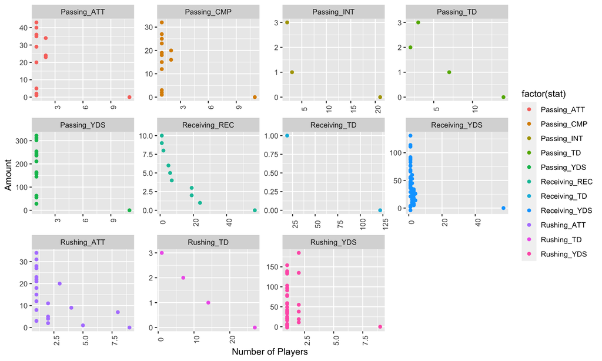

```r
# plotting a facet wrap with the stats
ggplot(subset(offCleanp, !is.na(Amount)), aes(y = Amount, colour = factor(stat))) + geom_point(stat='count') + facet_wrap(. ~ stat, scales="free") + xlab("Number of Players") + theme(axis.text.x = element_text(angle = 90))
```

### 3.

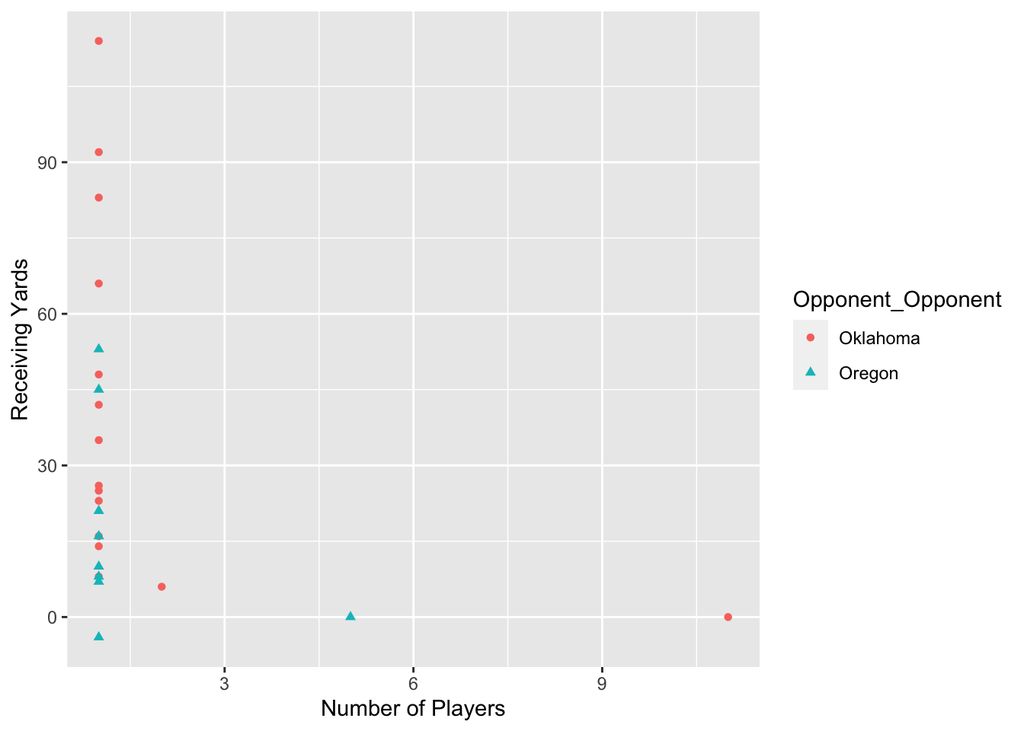

```r
# separating so we only have Oregon and Oklahoma Receiving Yard data
goodOffense <- offCleanp %>%
  filter(stat == "Receiving_YDS" & (Opponent_Opponent == "Oklahoma" | Opponent_Opponent == "Oregon") & !is.na(Amount))
# creating scatter plot and boxplot
ggplot(goodOffense, aes(y = Amount, colour = Opponent_Opponent, shape = Opponent_Opponent)) + geom_point(stat='count') + xlab("Number of Players") + ylab("Receiving Yards")
```

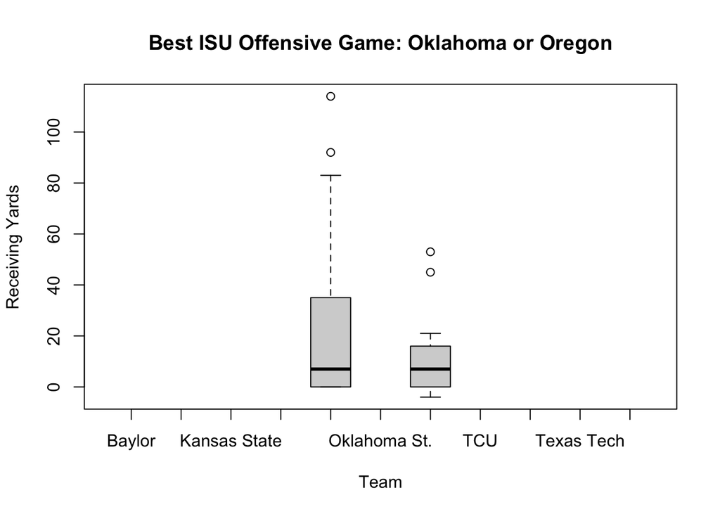

```r
boxplot(data = goodOffense, Amount~Opponent_Opponent, main = 'Best ISU Offensive Game: Oklahoma or Oregon',
        xlab = 'Team', ylab = 'Receiving Yards')
```

### 4.

We separated `Hometown` into `City` and `State` using the ‘,’ characters.

```r
biography <- separate(bioClean, `Hometown`, c('City', 'State'), sep=', ')
head(biography)
```

```
## # A tibble: 6 x 10
##   Name     Position      Ft    In Weight Class   City   State Highschool  Height
##   <fct>    <chr>      <dbl> <dbl>  <dbl> <chr>   <chr>  <chr> <chr>        <dbl>
## 1 Akers, … Wide Rece…     6     0    191 Redshi… Cedar… Iowa  Washington      72
## 2 Allen, … Tight End      6     7    240 Redshi… Nixa   Mo.   Nixa            79
## 3 Anderso… Wide Rece…     6     5    208 Redshi… Seffn… Fla.  Armwood         77
## 4 Antoine… Defensive…     6     0    180 Freshm… Ft. L… Fla.  Cardinal G…     72
## 5 Assalle… Placekick…     6     0    195 Redshi… Naper… Ill.  Central         72
## 6 Azunna,… Defensive…     6     0    199 Redshi… Grand… Texas Lake Ridge      72
```

### 5.

Based on the output, we can can read a few of the rows. For example, there are 42 players from Iowa, 4 players from Arizona, and even 1 player from Australia.

```r
biography %>% count(State)
```

```
## # A tibble: 21 x 2
##    State         n
##  * <chr>     <int>
##  1 Ariz.         4
##  2 Ark.          1
##  3 Australia     1
##  4 Calif.        2
##  5 Fla.         14
##  6 Ga.           3
##  7 Ill.          6
##  8 Iowa         42
##  9 Kan.          4
## 10 Mich          1
## # … with 11 more rows
```

# Part Three

### 1.

Based off of both numerical and graphical summaries, we can tell that the most frequent home state of offensive players at Iowa State is Florida with 3 players, while the most frequent home state for defensive players is Iowa with 10 players.

```r
# using inner join to get only offensive player names and states
OPlayers <- inner_join(biography, offClean, by = 'Name')
OPlayers <- OPlayers %>% select(Name, State)
OPlayers <- OPlayers %>% group_by(Name) %>% distinct()
OPlayers
```

```
## # A tibble: 16 x 2
## # Groups:   Name [16]
##    Name               State
##    <fct>              <chr>
##  1 Akers, Landen      Iowa
##  2 Allen, Chase       Mo.
##  3 Bitter, Aidan      Fla.
##  4 Brock, Jirehl      Ill.
##  5 Dean, Easton       Kan.
##  6 Dekkers, Hunter    Iowa
##  7 Hall, Breece       Kan.
##  8 Hutchinson, Xavier Fla.
##  9 Jackson, Daniel    Texas
## 10 Kolar, Charlie     Okla.
## 11 Milton, Tarique    Fla.
## 12 Nwangwu, Kene      Texas
## 13 Purdy, Brock       Ariz.
## 14 Scates, Joe        Ohio
## 15 Shaw Jr., Sean     Okla.
## 16 Soehner, Dylan     Ark.
```

```r
# using inner join to get only defensive player names and states
DPlayers <- inner_join(biography, defClean, by = 'Name')
DPlayers <- DPlayers %>% select(Name, State)
DPlayers <- DPlayers %>% group_by(Name) %>% distinct()
DPlayers
```

```
## # A tibble: 36 x 2
## # Groups:   Name [36]
##    Name             State
##    <fct>            <chr>
##  1 Akers, Landen    Iowa
##  2 Azunna, Arnold   Texas
##  3 Bailey, JaQuan   Fla.
##  4 Bailey, Joshua   Fla.
##  5 Brock, Jirehl    Ill.
##  6 Chambers, Mason  Texas
##  7 Davis, Dae'Shawn Ohio
##  8 Hathcock, Koby   Ariz.
##  9 Horne, Aric      Fla.
## 10 Hummel, Jake     Iowa
## # … with 26 more rows
```

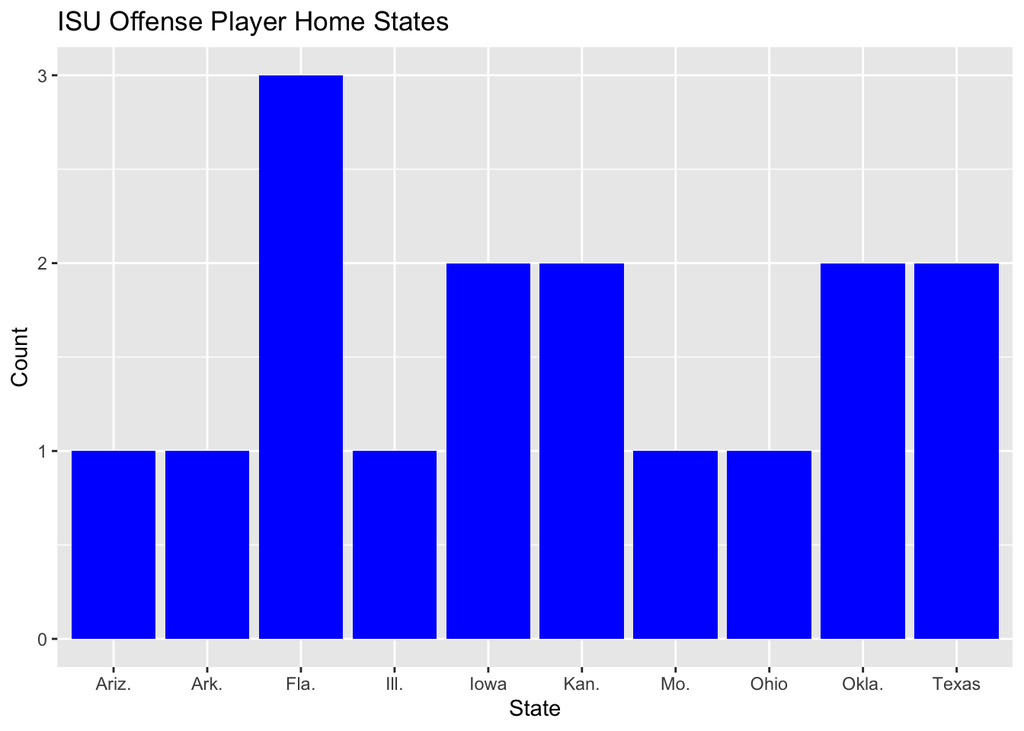

```r
# making states into factors for bar chart
DPlayers$State <- factor(DPlayers$State)
OPlayers$State <- factor(OPlayers$State)

# creating bar chart for offensive and defensive data
ggplot(OPlayers, aes(x = State)) + geom_bar(fill = 'blue') +
  ggtitle('ISU Offense Player Home States') + xlab('State') + ylab('Count')
```

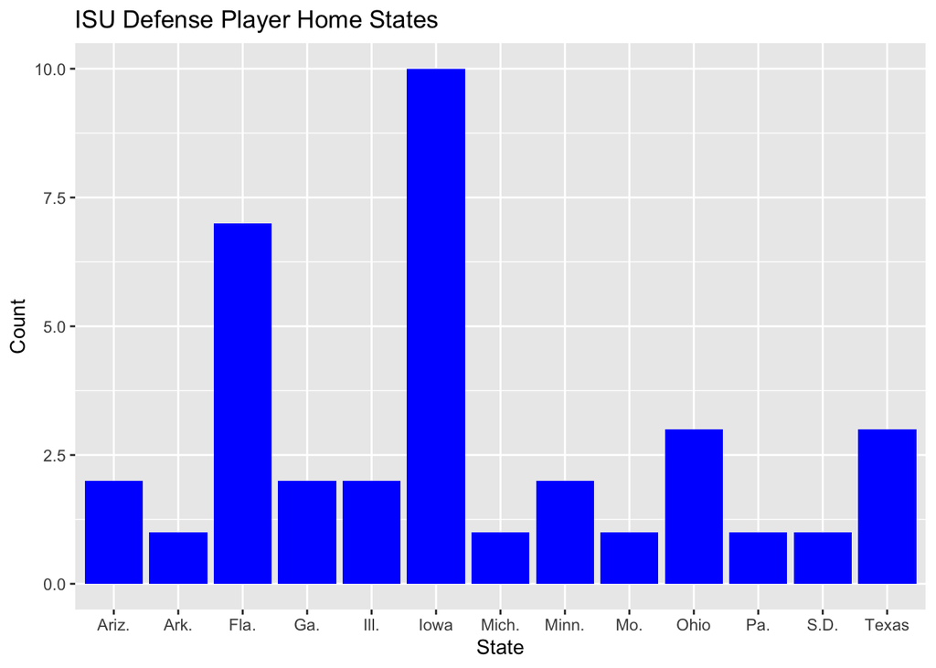

```r
ggplot(DPlayers, aes(x = State)) + geom_bar(fill = 'blue') +
  ggtitle('ISU Defense Player Home States') + xlab('State') + ylab('Count')
```

### 2.

For our analysis, we looked at the total yards that Purdy accumulated via rushing and passing, then compared those stats with the outcome of the game (either a win or loss). Zack found the win and loss data easily online and added that to the existing Purdy data frame. We then found that Purdy’s performance does seem to relate to the Iowa State’s performance as a team because in the graph shown, Purdy has the most total yards in the games where Iowa State wins. Looking closer, we can see that where there are clearly more than 200 total yards, Iowa State almost always won, while in 2 of the games where ISU lost (Louisiana and Oklahoma State), Purdy had noticeably fewer total yards. The exception to this is the second game against Oklahoma where Purdy had the highest number of total yards (300+), but ISU still lost.

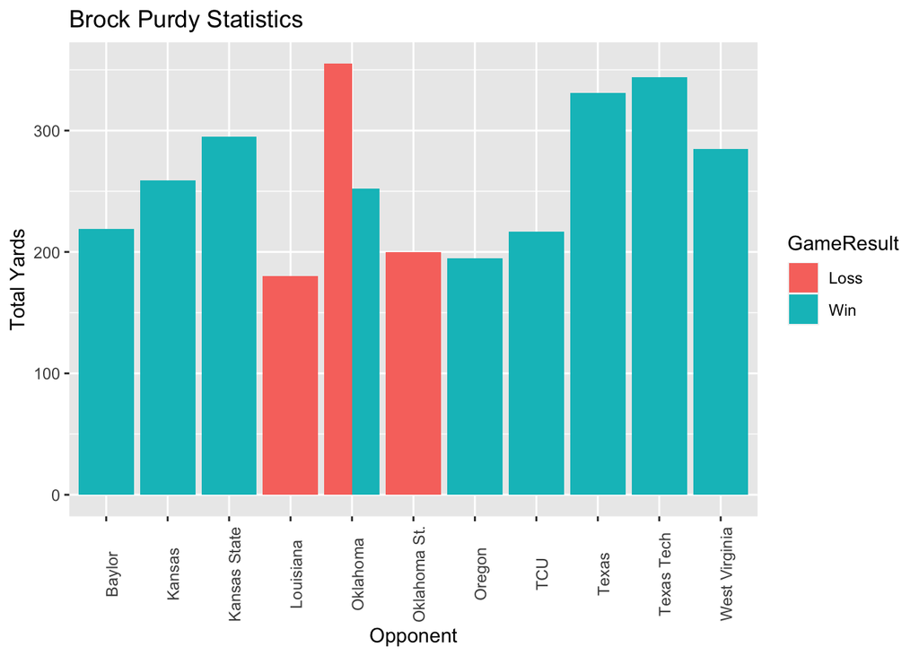

```r
# creating total yards column to use as purdy's primary stat
Purdy <- offClean %>% filter(Name == "Purdy, Brock")
Purdy <- Purdy %>% mutate(TotalYards = Passing_YDS + Rushing_YDS)
Purdy <- Purdy %>% select(Name, Opponent_Opponent, TotalYards)

#Found game results for each opponent online and added them to df to see team performance vs Purdy's performance
Purdy$GameResult <- c("Loss", "Win", "Win", "Win", "Loss", "Win", "Win", "Win", "Win", "Win", "Loss", "Win")
ggplot(Purdy, aes(x = factor(Opponent_Opponent), y = TotalYards,fill=GameResult)) +
  geom_histogram(stat = 'Identity', position = 'dodge') + ggtitle("Brock Purdy Statistics") +
  ylab("Total Yards") + xlab("Opponent") + theme(axis.text.x = element_text(angle = 90))
```

### 3.

We decided to focus the study of improvement on defensive players, more specifically looking at the average number of solo tackles in each game. We downloaded the 2019 data and compared that data to the current season’s data (2020) and found the 15 players who played in both years. Then we ordered them by the average number of tackles that they gained (or lost) per game from last year. In doing so, we found that Mike Rose, Jake Hummel, and JaQuan Bailey were among the most improved players on defense because they all got, on average, over one more solo tackle a game than the previous year (specifically 1.5, 1.41, and 1.17 more tackles, respectively).

```r
#Compare defense players' tackles after cleaning the 2019 data
defense2019 <- read_excel('./cyclonesFootball2019.xlsx', sheet = 'Defensive')

# fixing column names so the names are factors and stats are numeric
defense2019 <- defense2019 %>%
  mutate(across(c('Name','Opponent_Opponent'), as.factor),
         across(Tackles_Solo:Pass_PB, as.numeric))
# 2020 summaries
defense2020 <- defClean %>%
  group_by(Name) %>% distinct() %>%
  summarise(soloTacklesFrom2020 = mean(Tackles_Solo, na.rm = TRUE))
# 2019 summaries
defense2019 <- defense2019 %>%
  group_by(Name) %>% distinct() %>%
  summarise(soloTacklesFrom2019 = mean(Tackles_Solo, na.rm = TRUE))
# joining summaries into new data frame to compare
defenseImprovements <- inner_join(defense2020, defense2019, by = "Name")
# finding differences between 2019 and 2020
defenseImprovements <- defenseImprovements %>%
  mutate(numTacklesIncreased = soloTacklesFrom2020 - soloTacklesFrom2019)
# sorting by most improved
defenseImprovements[order(defenseImprovements$numTacklesIncreased, decreasing = TRUE),]
```

```
## # A tibble: 15 x 4
##    Name              soloTacklesFrom2020 soloTacklesFrom2019 numTacklesIncreased
##    <fct>                           <dbl>               <dbl>               <dbl>
##  1 Rose, Mike                      4.5                3                   1.5
##  2 Hummel, Jake                    3.33               1.92                1.41
##  3 Bailey, JaQuan                  1.67               0.5                 1.17
##  4 Vaughn, Gerry                   0.833              0.0769              0.756
##  5 Young, Datrone                  1.64               0.923               0.713
##  6 Walling, Rory                   0.545              0.231               0.315
##  7 King, Kym-Mani                  0.5                0.308               0.192
##  8 Rus, Jared                      0.182              0                   0.182
##  9 Azunna, Arnold                  1.67               1.64                0.0303
## 10 Uwazurike, Eyioma               1.33               1.46               -0.128
## 11 Soehner, Dylan                  0.1                0.25               -0.15
## 12 Vance, O'Rien                   2.5                2.83               -0.333
## 13 Akers, Landen                   0.25               0.692              -0.442
## 14 Petersen, Zach                  0.583              1.77               -1.19
## 15 Kyle, Tayvonn                   1.67               3.14               -1.48
```